# Polla_Lee_ps4

```python
import pandas as pd
import numpy as np
import sklearn
from sklearn.feature_extraction.text import CountVectorizer
import matplotlib.pyplot as plt
from sklearn.linear_model import Perceptron
from sklearn.neural_network import MLPClassifier
from sklearn.naive_bayes import MultinomialNB
from timeit import default_timer as timer
from sklearn.model_selection import cross_validate
import math
```

Lee Polla Problem Set 4 3/10/22

Dataset: IMDB text reviews with positive/negative sentiment

I chose this data set because I wanted to run a UCCA parser over the text to get a semantic annotation of the text data that wouldve been learned from a corpus of English Treebank reviews from the UCCA resources. I wanted to see what it would be like to try feeding these semantic features into correlative models to see if they produce different results from normal methods that use a purely correlative model and non-semantic text representations like a bag of words model.

This data was produced for a paper published in 2011 and there is not any other information readily available about how the data was collected

http://ai.stanford.edu/~amaas/data/sentiment/

# Research question, algorithm choice, initial challenges

~~Research question: How does the performance of classifiers for positive/negative sentiment analysis on reviews change when the representations of text is changed to add more features for each particular word. How would a hybrid model perform when additional features from semantic annotations are added into the bag of words model.

I would predict that a hybrid model with more features would add accuracy into the classifier, but if it performs on the same level as models that only use a bag of words for features, then that would mean that the information from semantic annotations is not compatible with simple correlative methods.

Research question: How does the performance of classifiers for positive/negative sentiment analysis on reviews change when the representations of text is changed to use/ignore stop words.

An important difference between semantic annotations of text and bag of word models is that stop words are very important for showing the grammatical structure of text, but they are typically removed in bag of words models. So another interesting question is how do models perform with and without stop words. Perhaps neural nets or n-grams are able to capture some of this grammatical structure by making connections between stop words and other words, so I would expect these methods to perform better than the simple bag of words model

Using a neural net or a naive bayes classifier is well suited for this problem because both of those methods are able to accept large numbers of features for NLP or make associations using stop words

Initial challenges: The reason why I was not able to try the UCCA annotations is because I was having difficulties with getting my C++ devtools setup for the parser package. I was also running out of memory on Jupyter notebook, so I figured that adding in more features would've just made that worse.

To get around some of the memory problems, I decided to just work with a small fraction of the 50,000 rows of text data. I also set the minimum frequency of terms to 5 for the counter, so this is also helping to limit the number of features

```python
review_text = pd.read_csv("IMDB Dataset.csv")
print(review_text.head)
```

```
<bound method NDFrame.head of                                                   review sentiment
0      One of the other reviewers has mentioned that ...  positive
1      A wonderful little production. <br /><br />The...  positive
2      I thought this was a wonderful way to spend ti...  positive
3      Basically there's a family where a little boy ...  negative
4      Petter Mattei's "Love in the Time of Money" is...  positive
...                                                  ...       ...
49995  I thought this movie did a down right good job...  positive
49996  Bad plot, bad dialogue, bad acting, idiotic di...  negative
49997  I am a Catholic taught in parochial elementary...  negative
49998  I'm going to have to disagree with the previou...  negative
49999  No one expects the Star Trek movies to be high...  negative

[50000 rows x 2 columns]>
```

```python
text_array = np.array(review_text['review'][:3500])
print(text_array[:2])
```

```
["One of the other reviewers has mentioned that after watching just 1 Oz episode you'll be hooked. They are right, as this is exactly what happened with me.<br /><br />The first thing that struck me about Oz was its brutality and unflinching scenes of violence, which set in right from the word GO. T…
 'A wonderful little production. <br /><br />The filming technique is very unassuming- very old-time-BBC fashion and gives a comforting, and sometimes discomforting, sense of realism to the entire piece. <br /><br />The actors are extremely well chosen- Michael Sheen not only "has got all the polari…
```

```python
from sklearn.model_selection import train_test_split

x_train, x_test, y_train, y_test  = train_test_split(
        np.array(range(3500)),
        np.array(review_text['sentiment'][:3500]),
        train_size=0.80,
        random_state=3)
```

```python
vectorizer = CountVectorizer(max_df = 0.4, min_df = 5)
counts = vectorizer.fit_transform(text_array)
print(counts)
print(vectorizer.get_feature_names())
print(np.shape(counts))
```

[output not shown]

```python
count_array = counts.toarray()
print(count_array[:10])
```

```
[[0 0 0 ... 0 0 0]
 [0 0 0 ... 0 0 0]
 [0 0 0 ... 0 0 0]
 ...
 [0 0 0 ... 0 0 0]
 [0 0 0 ... 0 0 0]
 [0 0 0 ... 0 0 0]]
```

# Tinkering

Here I am trying the difference between Logistic and rectified linear unit Next I will try another algorithm, Naive Bayes, on the full text and text with stop words removed Then I will try Neural nets again with different numbers of hidden layers

```python
from timeit import default_timer as timer
start = timer()
print("Fitting MLPClassifier to the data...")
m = MLPClassifier(hidden_layer_sizes= (50,),
                 activation="relu",
                 alpha=0.001,
                 tol=1e-6,
                 max_iter=100000).fit(count_array[x_train],y_train)
end = timer()
print(f"Done. Took {end-start:.2f} seconds")
#test_preds = m.predict(count_array[x_test])
print(m.score(count_array[x_test], y_test))
```

```
Fitting MLPClassifier to the data...
Done. Took 308.50 seconds
0.8157142857142857
```

```python
start = timer()
print("Fitting MLPClassifier to the data...")
m4 = MLPClassifier(hidden_layer_sizes= (50,),
                 activation="logistic",
                 alpha=0.001,
                 tol=1e-6,
                 max_iter=100000).fit(count_array[x_train],y_train)
end = timer()
print(f"Done. Took {end-start:.2f} seconds")
#test_preds = m4.predict(count_array[x_test])
print(m4.score(count_array[x_test], y_test))
```

```
Fitting MLPClassifier to the data...
Done. Took 436.28 seconds
0.8071428571428572
```

```python
stopfile = open("longstop.txt", "r")
stopwords = stopfile.read()
#print(stopwords)
stoplist = stopwords.split("\n")
stopfile.close()
print(stoplist)
```

```
['', 'a', 'able', 'about', 'above', 'abst', 'accordance', 'according', 'accordingly', 'across', 'act', 'actually', 'added', 'adj', 'affected', 'affecting', 'affects', 'after', 'afterwards', 'again', 'against', 'ah', 'all', 'almost', 'alone', 'along', 'already', 'also', 'although', 'always', 'am', 'a…
```

```python
len(stoplist)
```

```
668
```

```python
stop_vectorizer = CountVectorizer(max_df = 0.4, min_df = 5, stop_words = stoplist)
stop_counts = stop_vectorizer.fit_transform(text_array)
print(np.shape(stop_counts))
stop_array = stop_counts.toarray()
```

```
(3500, 8387)
```

```python
start = timer()
print("Fitting MLPClassifier to the data...")
m2 = MLPClassifier(hidden_layer_sizes= (50,),
                 activation="relu",
                 alpha=0.001,
                 tol=1e-6,
                 max_iter=100000).fit(stop_array[x_train],y_train)
end = timer()
print(f"Done. Took {end-start:.2f} seconds")
#test_preds = m2.predict(stop_array[x_test])
print(m2.score(stop_array[x_test], y_test))
```

```
Fitting MLPClassifier to the data...
Done. Took 131.64 seconds
0.8157142857142857
```

```python
start = timer()
print("Fitting MLPClassifier to the data...")
m3 = MLPClassifier(hidden_layer_sizes= (50,),
                 activation="logistic",
                 alpha=0.001,
                 tol=1e-6,
                 max_iter=100000).fit(stop_array[x_train],y_train)
end = timer()
print(f"Done. Took {end-start:.2f} seconds")
#test_preds = m3.predict(stop_array[x_test])
print(m3.score(stop_array[x_test], y_test))
```

```
Fitting MLPClassifier to the data...
Done. Took 164.43 seconds
0.8114285714285714
```

# results

It looks like the choice of activation method accounts for less than 0.01 of the accuracy score in both of the neural net models with words and with stop words removed. The ReLU function seemse to have slightly better performance.

```python
nb_full = MultinomialNB()
nb_full.fit(count_array[x_train], y_train)
nb_full.score(count_array[x_test], y_test)
```

```
0.8242857142857143
```

```python
nb_stop = MultinomialNB()
nb_stop.fit(stop_array[x_train], y_train)
nb_stop.score(stop_array[x_test], y_test)
```

```
0.83
```

```python
start = timer()
full_cv_results = cross_validate(nb_full, count_array, np.array(review_text['sentiment'][:3500]), cv = 10)
stop_cv_results = cross_validate(nb_stop, stop_array, np.array(review_text['sentiment'][:3500]), cv = 10)
end = timer()
print(f"Done. Took {end-start:.2f} seconds")
print("average full: " + str(np.average(full_cv_results['test_score'])))
print("average stop: " + str(np.average(stop_cv_results['test_score'])))
```

```
Done. Took 10.95 seconds
average full: 0.8302857142857143
average stop: 0.8305714285714286
```

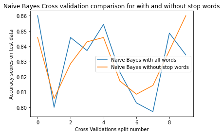

```python
plt.plot(range(10), full_cv_results['test_score'], label = "Naive Bayes with all words")
plt.plot(range(10), stop_cv_results['test_score'], label = "Naive Bayes without stop words")
plt.legend()
plt.title("Naive Bayes Cross validation comparison for with and without stop words")
plt.xlabel("Cross Validations split number")
plt.ylabel("Accuracy scores on test data")

plt.show()
```

# Results of Naive Bayes

```python
#test number of hidden layers

accuracy_scores_full = []
accuracy_scores_stop = []
layers = [1,5,10,15,20,25,30,35,40,45]
start = timer()
for i in layers:
    print('iteration : ' + str(i))
    m_full = MLPClassifier(hidden_layer_sizes= (i,),
                     activation="relu",
                     alpha=0.001,
                     tol=1e-6,
                     max_iter=100000).fit(count_array[x_train],y_train)
    accuracy_scores_full.append(m_full.score(count_array[x_test], y_test))

    m_stop = MLPClassifier(hidden_layer_sizes= (i,),
                 activation="relu",
                 alpha=0.001,
                 tol=1e-6,
                 max_iter=100000).fit(stop_array[x_train],y_train)
    accuracy_scores_stop.append(m_stop.score(stop_array[x_test], y_test))

end = timer()
print(f"Done. Took {end-start:.2f} seconds")
```

```
iteration : 1
iteration : 5
iteration : 10
iteration : 15
iteration : 20
iteration : 25
iteration : 30
iteration : 35
iteration : 40
iteration : 45
Done. Took 2832.92 seconds
```

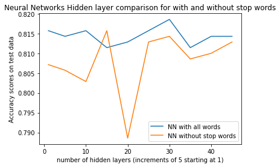

```python
plt.plot(layers, accuracy_scores_full, label = "NN with all words")
plt.plot(layers, accuracy_scores_stop, label = "NN without stop words")
plt.title("Neural Networks Hidden layer comparison for with and without stop words")
plt.xlabel("number of hidden layers (increments of 5 starting at 1)")
plt.ylabel("Accuracy scores on test data")
plt.legend()
plt.show()
```

```python
import math
z_diff = np.average(accuracy_scores_full) - np.average(accuracy_scores_stop)
z_std_sum = np.std(accuracy_scores_full) + np.std(accuracy_scores_stop)
z_score = z_diff / math.sqrt(z_std_sum)
print(z_score)
```

```
0.06724491834026824
```

# Results of testing hidden layers

It looks like the neural network model with all of the stop words included was able to perform better than the neural net without them. Maybe this is because there are some hidden layers that are learning to represent some grammatical structure in positive vs negative reviews.

```
iteration : 0
iteration : 1
iteration : 2
iteration : 3
iteration : 4
iteration : 5
iteration : 6
iteration : 7
iteration : 8
iteration : 9
Done. Took 3696.44 seconds
```

[figure not shown]

```python
cv_scores_full = []
cv_scores_stop = []

start = timer()
for i in range(10):
    print('iteration : ' + str(i))
    x_train, x_test, y_train, y_test  = train_test_split(
        np.array(range(3500)),
        np.array(review_text['sentiment'][:3500]),
        train_size=0.80,
        random_state=i)
    m_full = MLPClassifier(hidden_layer_sizes= (15,),
                     activation="relu",
                     alpha=0.001,
                     tol=1e-6,
                     max_iter=100000).fit(count_array[x_train],y_train)
    cv_scores_full.append(m_full.score(count_array[x_test], y_test))

    m_stop = MLPClassifier(hidden_layer_sizes= (15,),
                 activation="relu",
                 alpha=0.001,
                 tol=1e-6,
                 max_iter=100000).fit(stop_array[x_train],y_train)
    cv_scores_stop.append(m_stop.score(stop_array[x_test], y_test))

end = timer()
print(f"Done. Took {end-start:.2f} seconds")

plt.plot(range(10), cv_scores_full, label = "NN with all words")
plt.plot(range(10), cv_scores_stop, label = "NN without stop words")
plt.title("Neural Networks Cross validation comparison for with and without stop words")
plt.xlabel("Cross Validations split number")
plt.ylabel("Accuracy scores on test data")
plt.legend()
plt.show()
```

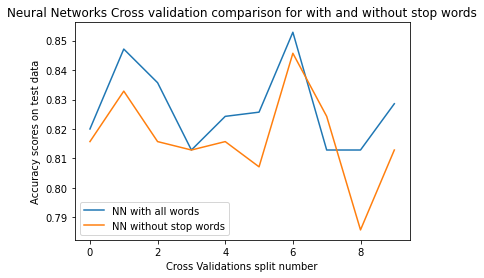

```python
plt.plot(range(10), cv_scores_full, label = "NN with all words")
plt.plot(range(10), cv_scores_stop, label = "NN without stop words")
plt.title("Neural Networks Cross validation comparison for with and without stop words")
plt.xlabel("Cross Validations split number")
plt.ylabel("Accuracy scores on test data")
plt.legend()
plt.show()
```

# Overall results

In all of the tests that I performed, the differences in accuracy were usually very small, so it seems like the choice to add or remove stop words might only account for a small difference in results. Stop words seem to account for 1/10 of the words at most, but might only improve accuracy by 1%. When comparing between Naive Bayes and Neural nets, it seems like they result in the similar accuracy scores but Naive Bayes runs much faster. So we should prefer the naive bayes model for the speed.

I ran cross validation on some of the tests, so I think I am confident that the choice of stop words does not change the accuracy of naive bayes but does result in a 1% difference in neural nets where including more features from stop words results in higher accuracy.

I am also worried that being limited to just 1000s of rows mightve also affected the results adversely

# Potential harms and benefits

I think that representing sentiment for the entire content of a sentence is an oversimplification of speech, so it will not be able to accurately categorize speech from different cultural situations or social norms. For example, in some polite societies saying 'pretty good' is actually the polite way of expressing negative sentiment towards a subject but expressing a positive sentiment towards their audience. So this algorithm using stop words in those ambiguous phrases might not be able to analyze polite speech and could disadvantage people who speak differently.

Another problem with grammatical representations of language is that there is a normative component where the model learns to expect the dominant perspective based on the data. For example, the model might not be able to properly classify text written in African-American Vernacular English based on the different grammatical structure or usage of stop words. So this would disadvantage margninalized groups who use English differently in general, including people who use English as a secondary language.

An advantage of semantic representations in text is that models will be able to handle different contexts in more relevant ways. To augment the models that just find associations between words, a semantic representations can give the model a context independent representation of some words and this could help applications like chat bots give more intelligible responses to unexpected dialogue.

The other advantage of semantic representations is that it gives more interpretability to the model for explaining human speech. Stop words can be used to help represent linguistic rules for implicature and help distinguish between speaker meaning and sentence meaning. This can allow models to extract specific facts from text in ways that are more easily understood.

# Future research questions

I think the most important difference between the Naive bayes and the Neural nets is that the neural nets saw some increase in accuracy from using the stop words. Even though neural nets are not really interpretable, I think that in some of the hidden layers there are nodes that are learning about grammitical relationships in some ways. To test how this is happening, I would want to think about designing a neural net with some specifications about hidden layers that are meant to encourage finding grammatical relationships. Like if there was a hidden layer that checked if the words as features were used in the same sentence, then that could indicate that a grammatical relationship might be learned instead of a general word occurence relationship.

I am still unsure about how I can actually apply the UCCA data to a neural net implementation, because each word in the annotation will have a data about where in the text it occurs and information about parts of speech tags that cannot be included in a bag of words model, so a new representation might require a much larger amount of features, possibly 15 times bigger to represent all possible combinations of words with parts of speech and possibly 100s of times bigger to represent the location of words in text. Testing this could help us know if our models are getting things correct for the right reasons.

I would also be interested in testing more with bigram or n gram representations, but I was limited by some memory problems. If I had the computational resources then I would've liked to try the models with the full 50k rows of data instead of just 3500.